# Generating initial ATAC_counts

## ATAC-Seq Step 1: QC

Our first step in evaluating ATAC-Seq data is by running a variety of QC measures. We will operate on the dba object from diffbind to store the reads (bams) from our samples. For simplicity of github, we will just be working with the final object, but the bams for our Human data can be found at CREST2 `/data/Austin/workdir/NC_Timecourse_Data/Human_ESC_ATAC/BAM`

[output not shown]

```
[1] 62
```

```
snapshotDate(): 2019-10-29
loading from cache
require(“ensembldb”)
```

```
$ATAC_ES_D0_1_toGRCh38_sorted_nodups
$ATAC_ES_D0_1_toGRCh38_sorted_nodups[[1]]
```

| seqnames | seqlength | mapped | unmapped |
| --- | --- | --- | --- |
| chr1 | 248956422 | 3670452 | 0 |
| chr2 | 242193529 | 2870354 | 0 |
| chr3 | 198295559 | 2281318 | 0 |
| chr4 | 190214555 | 1837104 | 0 |
| chr5 | 181538259 | 2078920 | 0 |
| chr6 | 170805979 | 2131462 | 0 |
| chr7 | 159345973 | 1988908 | 0 |
| chr8 | 145138636 | 1634202 | 0 |
| chr9 | 138394717 | 1613736 | 0 |
| chr10 | 133797422 | 1686988 | 0 |

[output cut: 185 more lines]

```
$ATAC_ES_D0_1_toGRCh38_sorted_nodups[[2]]

$ATAC_ES_D0_1_toGRCh38_sorted_nodups[[3]]
[1] 1.706311

$ATAC_ES_D0_1_toGRCh38_sorted_nodups[[4]]

$ATAC_ES_D0_1_toGRCh38_sorted_nodups[[5]]
Annotated peaks generated by ChIPseeker
10188/10188  peaks were annotated
Genomic Annotation Summary:
```

|  | Feature | Frequency |
| --- | --- | --- |
| 9 | Promoter (<=1kb) | 23.5374951 |
| 10 | Promoter (1-2kb) | 2.8268551 |
| 11 | Promoter (2-3kb) | 2.4636828 |
| 4 | 5' UTR | 0.2355713 |
| 3 | 3' UTR | 1.7569690 |
| 1 | 1st Exon | 2.2673734 |
| 7 | Other Exon | 2.8563015 |
| 2 | 1st Intron | 10.6105222 |
| 8 | Other Intron | 24.1951315 |
| 6 | Downstream (<=300) | 0.6870828 |

[output cut: 1 more lines]

```
$ATAC_ES_D0_2_toGRCh38_sorted_nodups
$ATAC_ES_D0_2_toGRCh38_sorted_nodups[[1]]
```

| seqnames | seqlength | mapped | unmapped |
| --- | --- | --- | --- |
| chr1 | 248956422 | 3121976 | 0 |
| chr2 | 242193529 | 2472416 | 0 |
| chr3 | 198295559 | 1980514 | 0 |
| chr4 | 190214555 | 1622090 | 0 |
| chr5 | 181538259 | 1809398 | 0 |
| chr6 | 170805979 | 1816406 | 0 |
| chr7 | 159345973 | 1724178 | 0 |
| chr8 | 145138636 | 1432720 | 0 |
| chr9 | 138394717 | 1388034 | 0 |
| chr10 | 133797422 | 1466112 | 0 |

[output cut: 185 more lines]

```
$ATAC_ES_D0_2_toGRCh38_sorted_nodups[[2]]

$ATAC_ES_D0_2_toGRCh38_sorted_nodups[[3]]
[1] 1.801158

$ATAC_ES_D0_2_toGRCh38_sorted_nodups[[4]]

$ATAC_ES_D0_2_toGRCh38_sorted_nodups[[5]]
Annotated peaks generated by ChIPseeker
9862/9862  peaks were annotated
Genomic Annotation Summary:
```

|  | Feature | Frequency |
| --- | --- | --- |
| 9 | Promoter (<=1kb) | 25.3802474 |
| 10 | Promoter (1-2kb) | 2.8493206 |
| 11 | Promoter (2-3kb) | 2.6161022 |
| 4 | 5' UTR | 0.2433583 |
| 3 | 3' UTR | 1.4702900 |
| 1 | 1st Exon | 2.3119043 |
| 7 | Other Exon | 2.6668019 |
| 2 | 1st Intron | 10.0283918 |
| 8 | Other Intron | 23.5550598 |
| 6 | Downstream (<=300) | 0.8111945 |

[output cut: 1 more lines]

```
$ATAC_Mel_D5_1_toGRCh38_sorted_nodups
$ATAC_Mel_D5_1_toGRCh38_sorted_nodups[[1]]
```

| seqnames | seqlength | mapped | unmapped |
| --- | --- | --- | --- |
| chr1 | 248956422 | 2696304 | 0 |
| chr2 | 242193529 | 2063420 | 0 |
| chr3 | 198295559 | 1641020 | 0 |
| chr4 | 190214555 | 1265694 | 0 |
| chr5 | 181538259 | 1496610 | 0 |
| chr6 | 170805979 | 1420260 | 0 |
| chr7 | 159345973 | 1381586 | 0 |
| chr8 | 145138636 | 1179700 | 0 |
| chr9 | 138394717 | 1199200 | 0 |
| chr10 | 133797422 | 1253036 | 0 |

[output cut: 185 more lines]

```
$ATAC_Mel_D5_1_toGRCh38_sorted_nodups[[2]]

$ATAC_Mel_D5_1_toGRCh38_sorted_nodups[[3]]
[1] 3.130909

$ATAC_Mel_D5_1_toGRCh38_sorted_nodups[[4]]

$ATAC_Mel_D5_1_toGRCh38_sorted_nodups[[5]]
Annotated peaks generated by ChIPseeker
7406/7406  peaks were annotated
Genomic Annotation Summary:
```

|  | Feature | Frequency |
| --- | --- | --- |
| 9 | Promoter (<=1kb) | 25.1147718 |
| 10 | Promoter (1-2kb) | 3.3081285 |
| 11 | Promoter (2-3kb) | 2.4844720 |
| 4 | 5' UTR | 0.1350257 |
| 3 | 3' UTR | 1.1882258 |
| 1 | 1st Exon | 1.7823386 |
| 7 | Other Exon | 2.2549284 |
| 2 | 1st Intron | 10.6535242 |
| 8 | Other Intron | 23.9400486 |
| 6 | Downstream (<=300) | 0.5401026 |

[output cut: 1 more lines]

```
$ATAC_Mel_D5_2_toGRCh38_sorted_nodups
$ATAC_Mel_D5_2_toGRCh38_sorted_nodups[[1]]
```

| seqnames | seqlength | mapped | unmapped |
| --- | --- | --- | --- |
| chr1 | 248956422 | 2435212 | 0 |
| chr2 | 242193529 | 1878272 | 0 |
| chr3 | 198295559 | 1495658 | 0 |
| chr4 | 190214555 | 1159176 | 0 |
| chr5 | 181538259 | 1361956 | 0 |
| chr6 | 170805979 | 1299454 | 0 |
| chr7 | 159345973 | 1251916 | 0 |
| chr8 | 145138636 | 1075900 | 0 |
| chr9 | 138394717 | 1086448 | 0 |
| chr10 | 133797422 | 1130918 | 0 |

[output cut: 185 more lines]

```
$ATAC_Mel_D5_2_toGRCh38_sorted_nodups[[2]]

$ATAC_Mel_D5_2_toGRCh38_sorted_nodups[[3]]
[1] 3.172768

$ATAC_Mel_D5_2_toGRCh38_sorted_nodups[[4]]

$ATAC_Mel_D5_2_toGRCh38_sorted_nodups[[5]]
Annotated peaks generated by ChIPseeker
6544/6544  peaks were annotated
Genomic Annotation Summary:
```

|  | Feature | Frequency |
| --- | --- | --- |
| 9 | Promoter (<=1kb) | 26.7573350 |
| 10 | Promoter (1-2kb) | 2.9951100 |
| 11 | Promoter (2-3kb) | 2.3227384 |
| 4 | 5' UTR | 0.1680929 |
| 3 | 3' UTR | 1.2224939 |
| 1 | 1st Exon | 1.8795844 |
| 7 | Other Exon | 2.0782396 |
| 2 | 1st Intron | 10.5134474 |
| 8 | Other Intron | 22.6008557 |
| 6 | Downstream (<=300) | 0.7182152 |

[output cut: 1 more lines]

```
$ATAC_Myo_D14_1_toGRCh38_sorted_nodups
$ATAC_Myo_D14_1_toGRCh38_sorted_nodups[[1]]
```

| seqnames | seqlength | mapped | unmapped |
| --- | --- | --- | --- |
| chr1 | 248956422 | 1812402 | 0 |
| chr2 | 242193529 | 1484316 | 0 |
| chr3 | 198295559 | 1138602 | 0 |
| chr4 | 190214555 | 1008720 | 0 |
| chr5 | 181538259 | 1075402 | 0 |
| chr6 | 170805979 | 1028836 | 0 |
| chr7 | 159345973 | 981244 | 0 |
| chr8 | 145138636 | 847820 | 0 |
| chr9 | 138394717 | 816852 | 0 |
| chr10 | 133797422 | 847478 | 0 |

[output cut: 185 more lines]

```
$ATAC_Myo_D14_1_toGRCh38_sorted_nodups[[2]]

$ATAC_Myo_D14_1_toGRCh38_sorted_nodups[[3]]
[1] 4.571425

$ATAC_Myo_D14_1_toGRCh38_sorted_nodups[[4]]

$ATAC_Myo_D14_1_toGRCh38_sorted_nodups[[5]]
Annotated peaks generated by ChIPseeker
5384/5384  peaks were annotated
Genomic Annotation Summary:
```

|  | Feature | Frequency |
| --- | --- | --- |
| 9 | Promoter (<=1kb) | 25.4829123 |
| 10 | Promoter (1-2kb) | 3.5104012 |
| 11 | Promoter (2-3kb) | 2.1545319 |
| 4 | 5' UTR | 0.1671620 |
| 3 | 3' UTR | 1.4487370 |
| 1 | 1st Exon | 1.3187221 |
| 7 | Other Exon | 2.1359584 |
| 2 | 1st Intron | 11.6084695 |
| 8 | Other Intron | 25.1114413 |
| 6 | Downstream (<=300) | 0.5572065 |

[output cut: 1 more lines]

```
$ATAC_Myo_D14_2_toGRCh38_sorted_nodups
$ATAC_Myo_D14_2_toGRCh38_sorted_nodups[[1]]
```

| seqnames | seqlength | mapped | unmapped |
| --- | --- | --- | --- |
| chr1 | 248956422 | 1951318 | 0 |
| chr2 | 242193529 | 1577322 | 0 |
| chr3 | 198295559 | 1244776 | 0 |
| chr4 | 190214555 | 989096 | 0 |
| chr5 | 181538259 | 1125110 | 0 |
| chr6 | 170805979 | 1082378 | 0 |
| chr7 | 159345973 | 1044426 | 0 |
| chr8 | 145138636 | 901312 | 0 |
| chr9 | 138394717 | 896424 | 0 |
| chr10 | 133797422 | 940272 | 0 |

[output cut: 185 more lines]

```
$ATAC_Myo_D14_2_toGRCh38_sorted_nodups[[2]]

$ATAC_Myo_D14_2_toGRCh38_sorted_nodups[[3]]
[1] 2.619628

$ATAC_Myo_D14_2_toGRCh38_sorted_nodups[[4]]

$ATAC_Myo_D14_2_toGRCh38_sorted_nodups[[5]]
Annotated peaks generated by ChIPseeker
8501/8501  peaks were annotated
Genomic Annotation Summary:
```

|  | Feature | Frequency |
| --- | --- | --- |
| 9 | Promoter (<=1kb) | 20.2564404 |
| 10 | Promoter (1-2kb) | 3.3290201 |
| 11 | Promoter (2-3kb) | 2.2585578 |
| 4 | 5' UTR | 0.1058699 |
| 3 | 3' UTR | 1.1998588 |
| 1 | 1st Exon | 1.4233620 |
| 7 | Other Exon | 2.1173980 |
| 2 | 1st Intron | 11.9868251 |
| 8 | Other Intron | 28.1613928 |
| 6 | Downstream (<=300) | 0.5528761 |

[output cut: 1 more lines]

```
$ATAC_NC_D3_1_toGRCh38_sorted_nodups
$ATAC_NC_D3_1_toGRCh38_sorted_nodups[[1]]
```

| seqnames | seqlength | mapped | unmapped |
| --- | --- | --- | --- |
| chr1 | 248956422 | 3333920 | 0 |
| chr2 | 242193529 | 2543538 | 0 |
| chr3 | 198295559 | 2017742 | 0 |
| chr4 | 190214555 | 1537682 | 0 |
| chr5 | 181538259 | 1838024 | 0 |
| chr6 | 170805979 | 1818764 | 0 |
| chr7 | 159345973 | 1742502 | 0 |
| chr8 | 145138636 | 1440942 | 0 |
| chr9 | 138394717 | 1440762 | 0 |
| chr10 | 133797422 | 1496610 | 0 |

[output cut: 185 more lines]

```
$ATAC_NC_D3_1_toGRCh38_sorted_nodups[[2]]

$ATAC_NC_D3_1_toGRCh38_sorted_nodups[[3]]
[1] 1.772585

$ATAC_NC_D3_1_toGRCh38_sorted_nodups[[4]]

$ATAC_NC_D3_1_toGRCh38_sorted_nodups[[5]]
Annotated peaks generated by ChIPseeker
9997/9997  peaks were annotated
Genomic Annotation Summary:
```

|  | Feature | Frequency |
| --- | --- | --- |
| 9 | Promoter (<=1kb) | 22.7468240 |
| 10 | Promoter (1-2kb) | 2.8608583 |
| 11 | Promoter (2-3kb) | 2.6207862 |
| 4 | 5' UTR | 0.1700510 |
| 3 | 3' UTR | 1.5704711 |
| 1 | 1st Exon | 2.0506152 |
| 7 | Other Exon | 2.8608583 |
| 2 | 1st Intron | 10.2130639 |
| 8 | Other Intron | 24.5273582 |
| 6 | Downstream (<=300) | 0.8902671 |

[output cut: 1 more lines]

```
$ATAC_NC_D3_2_toGRCh38_sorted_nodups
$ATAC_NC_D3_2_toGRCh38_sorted_nodups[[1]]
```

| seqnames | seqlength | mapped | unmapped |
| --- | --- | --- | --- |
| chr1 | 248956422 | 2344554 | 0 |
| chr2 | 242193529 | 1785222 | 0 |
| chr3 | 198295559 | 1417804 | 0 |
| chr4 | 190214555 | 1086488 | 0 |
| chr5 | 181538259 | 1293976 | 0 |
| chr6 | 170805979 | 1279902 | 0 |
| chr7 | 159345973 | 1225308 | 0 |
| chr8 | 145138636 | 1017268 | 0 |
| chr9 | 138394717 | 1018602 | 0 |
| chr10 | 133797422 | 1055096 | 0 |

[output cut: 185 more lines]

```
$ATAC_NC_D3_2_toGRCh38_sorted_nodups[[2]]

$ATAC_NC_D3_2_toGRCh38_sorted_nodups[[3]]
[1] 2.149499

$ATAC_NC_D3_2_toGRCh38_sorted_nodups[[4]]

$ATAC_NC_D3_2_toGRCh38_sorted_nodups[[5]]
Annotated peaks generated by ChIPseeker
8285/8285  peaks were annotated
Genomic Annotation Summary:
```

|  | Feature | Frequency |
| --- | --- | --- |
| 9 | Promoter (<=1kb) | 25.0331925 |
| 10 | Promoter (1-2kb) | 3.1502716 |
| 11 | Promoter (2-3kb) | 2.4019312 |
| 4 | 5' UTR | 0.1931201 |
| 3 | 3' UTR | 1.4604707 |
| 1 | 1st Exon | 1.9553410 |
| 7 | Other Exon | 2.6674713 |
| 2 | 1st Intron | 9.8008449 |
| 8 | Other Intron | 23.3796017 |
| 6 | Downstream (<=300) | 0.7483404 |

[output cut: 1 more lines]

```
$ATAC_NC_D5_1_toGRCh38_sorted_nodups
$ATAC_NC_D5_1_toGRCh38_sorted_nodups[[1]]
```

| seqnames | seqlength | mapped | unmapped |
| --- | --- | --- | --- |
| chr1 | 248956422 | 2566092 | 0 |
| chr2 | 242193529 | 2005014 | 0 |
| chr3 | 198295559 | 1567190 | 0 |
| chr4 | 190214555 | 1207688 | 0 |
| chr5 | 181538259 | 1430572 | 0 |
| chr6 | 170805979 | 1385502 | 0 |
| chr7 | 159345973 | 1323070 | 0 |
| chr8 | 145138636 | 1138924 | 0 |
| chr9 | 138394717 | 1128000 | 0 |
| chr10 | 133797422 | 1201750 | 0 |

[output cut: 185 more lines]

```
$ATAC_NC_D5_1_toGRCh38_sorted_nodups[[2]]

$ATAC_NC_D5_1_toGRCh38_sorted_nodups[[3]]
[1] 1.949682

$ATAC_NC_D5_1_toGRCh38_sorted_nodups[[4]]

$ATAC_NC_D5_1_toGRCh38_sorted_nodups[[5]]
Annotated peaks generated by ChIPseeker
8244/8244  peaks were annotated
Genomic Annotation Summary:
```

|  | Feature | Frequency |
| --- | --- | --- |
| 9 | Promoter (<=1kb) | 24.3934983 |
| 10 | Promoter (1-2kb) | 2.8748180 |
| 11 | Promoter (2-3kb) | 2.2925764 |
| 4 | 5' UTR | 0.2062106 |
| 3 | 3' UTR | 1.2979136 |
| 1 | 1st Exon | 2.1470160 |
| 7 | Other Exon | 2.6322174 |
| 2 | 1st Intron | 10.0072780 |
| 8 | Other Intron | 24.1023775 |
| 6 | Downstream (<=300) | 0.5943717 |

[output cut: 1 more lines]

```
$ATAC_NC_D5_2_toGRCh38_sorted_nodups
$ATAC_NC_D5_2_toGRCh38_sorted_nodups[[1]]
```

| seqnames | seqlength | mapped | unmapped |
| --- | --- | --- | --- |
| chr1 | 248956422 | 3179226 | 0 |
| chr2 | 242193529 | 2468552 | 0 |
| chr3 | 198295559 | 1927628 | 0 |
| chr4 | 190214555 | 1498904 | 0 |
| chr5 | 181538259 | 1778466 | 0 |
| chr6 | 170805979 | 1715744 | 0 |
| chr7 | 159345973 | 1636508 | 0 |
| chr8 | 145138636 | 1408350 | 0 |
| chr9 | 138394717 | 1388758 | 0 |
| chr10 | 133797422 | 1481822 | 0 |

[output cut: 185 more lines]

```
$ATAC_NC_D5_2_toGRCh38_sorted_nodups[[2]]

$ATAC_NC_D5_2_toGRCh38_sorted_nodups[[3]]
[1] 2.648468

$ATAC_NC_D5_2_toGRCh38_sorted_nodups[[4]]

$ATAC_NC_D5_2_toGRCh38_sorted_nodups[[5]]
Annotated peaks generated by ChIPseeker
9235/9235  peaks were annotated
Genomic Annotation Summary:
```

|  | Feature | Frequency |
| --- | --- | --- |
| 9 | Promoter (<=1kb) | 21.5051435 |
| 10 | Promoter (1-2kb) | 2.7395777 |
| 11 | Promoter (2-3kb) | 2.1331890 |
| 4 | 5' UTR | 0.2165674 |
| 3 | 3' UTR | 1.2885761 |
| 1 | 1st Exon | 2.0465620 |
| 7 | Other Exon | 2.6312940 |
| 2 | 1st Intron | 10.3735788 |
| 8 | Other Intron | 25.2950731 |
| 6 | Downstream (<=300) | 0.7146724 |

[output cut: 1 more lines]

```
$ATAC_Neuron_D5_1_toGRCh38_sorted_nodups
$ATAC_Neuron_D5_1_toGRCh38_sorted_nodups[[1]]
```

| seqnames | seqlength | mapped | unmapped |
| --- | --- | --- | --- |
| chr1 | 248956422 | 1608484 | 0 |
| chr2 | 242193529 | 1376460 | 0 |
| chr3 | 198295559 | 1097108 | 0 |
| chr4 | 190214555 | 972868 | 0 |
| chr5 | 181538259 | 1032208 | 0 |
| chr6 | 170805979 | 938866 | 0 |
| chr7 | 159345973 | 931434 | 0 |
| chr8 | 145138636 | 824400 | 0 |
| chr9 | 138394717 | 745750 | 0 |
| chr10 | 133797422 | 818932 | 0 |

[output cut: 185 more lines]

```
$ATAC_Neuron_D5_1_toGRCh38_sorted_nodups[[2]]

$ATAC_Neuron_D5_1_toGRCh38_sorted_nodups[[3]]
[1] 3.800162

$ATAC_Neuron_D5_1_toGRCh38_sorted_nodups[[4]]

$ATAC_Neuron_D5_1_toGRCh38_sorted_nodups[[5]]
Annotated peaks generated by ChIPseeker
1471/1471  peaks were annotated
Genomic Annotation Summary:
```

|  | Feature | Frequency |
| --- | --- | --- |
| 9 | Promoter (<=1kb) | 61.79469748 |
| 10 | Promoter (1-2kb) | 2.37933379 |
| 11 | Promoter (2-3kb) | 0.95173351 |
| 4 | 5' UTR | 0.06798097 |
| 3 | 3' UTR | 0.67980965 |
| 1 | 1st Exon | 1.42760027 |
| 7 | Other Exon | 0.95173351 |
| 2 | 1st Intron | 4.48674371 |
| 8 | Other Intron | 9.85723997 |
| 6 | Downstream (<=300) | 0.40788579 |

[output cut: 1 more lines]

```
$ATAC_Neuron_D5_2_toGRCh38_sorted_nodups
$ATAC_Neuron_D5_2_toGRCh38_sorted_nodups[[1]]
```

| seqnames | seqlength | mapped | unmapped |
| --- | --- | --- | --- |
| chr1 | 248956422 | 2125984 | 0 |
| chr2 | 242193529 | 1776152 | 0 |
| chr3 | 198295559 | 1497228 | 0 |
| chr4 | 190214555 | 1298590 | 0 |
| chr5 | 181538259 | 1374554 | 0 |
| chr6 | 170805979 | 1262510 | 0 |
| chr7 | 159345973 | 1230856 | 0 |
| chr8 | 145138636 | 1106608 | 0 |
| chr9 | 138394717 | 1010178 | 0 |
| chr10 | 133797422 | 1100482 | 0 |

[output cut: 185 more lines]

```
$ATAC_Neuron_D5_2_toGRCh38_sorted_nodups[[2]]

$ATAC_Neuron_D5_2_toGRCh38_sorted_nodups[[3]]
[1] 4.249256

$ATAC_Neuron_D5_2_toGRCh38_sorted_nodups[[4]]

$ATAC_Neuron_D5_2_toGRCh38_sorted_nodups[[5]]
Annotated peaks generated by ChIPseeker
2548/2548  peaks were annotated
Genomic Annotation Summary:
```

|  | Feature | Frequency |
| --- | --- | --- |
| 9 | Promoter (<=1kb) | 47.48822606 |
| 10 | Promoter (1-2kb) | 2.78649922 |
| 11 | Promoter (2-3kb) | 1.76609105 |
| 4 | 5' UTR | 0.03924647 |
| 3 | 3' UTR | 0.74568289 |
| 1 | 1st Exon | 1.96232339 |
| 7 | Other Exon | 1.25588697 |
| 2 | 1st Intron | 6.55416013 |
| 8 | Other Intron | 14.63893250 |
| 6 | Downstream (<=300) | 0.47095761 |

[output cut: 1 more lines]

```
NANA
```

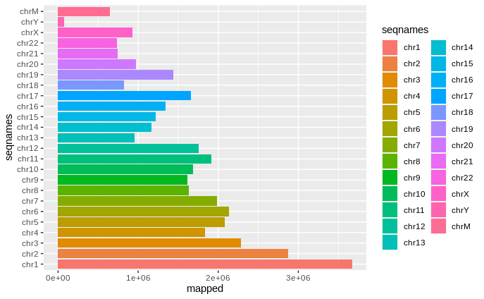

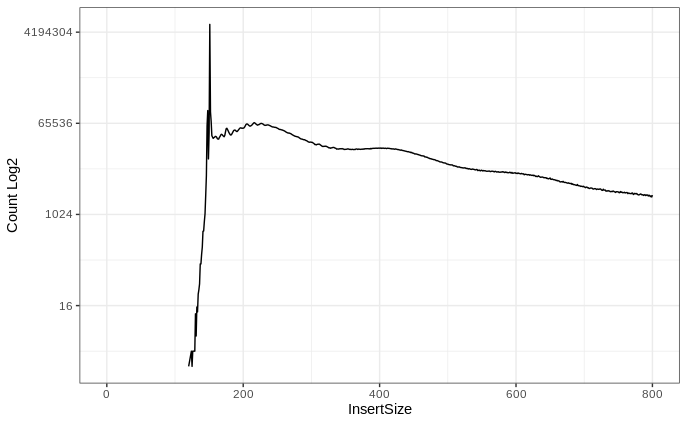

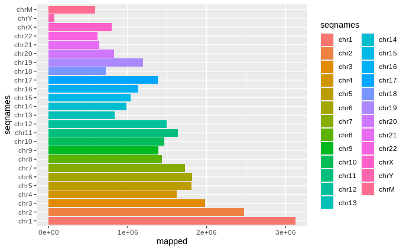

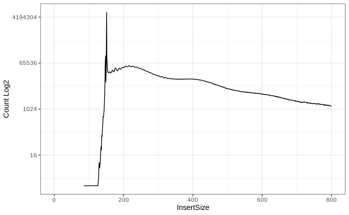

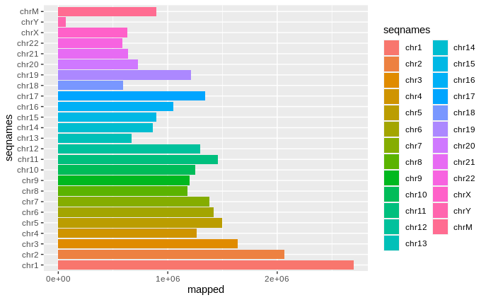

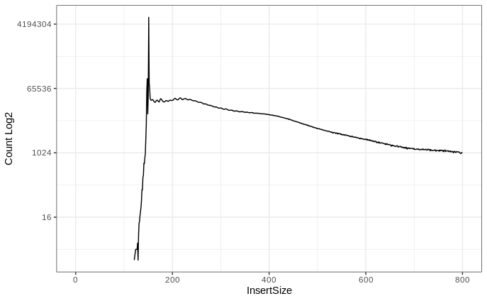

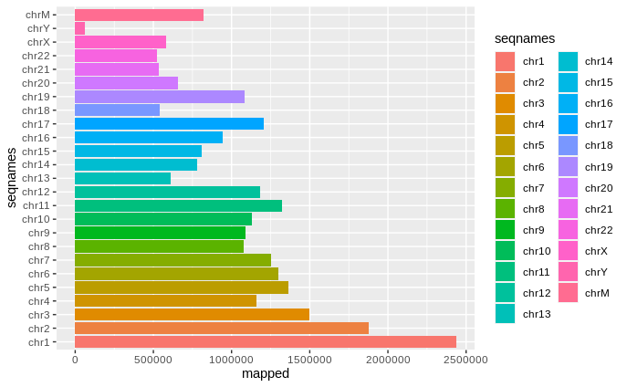

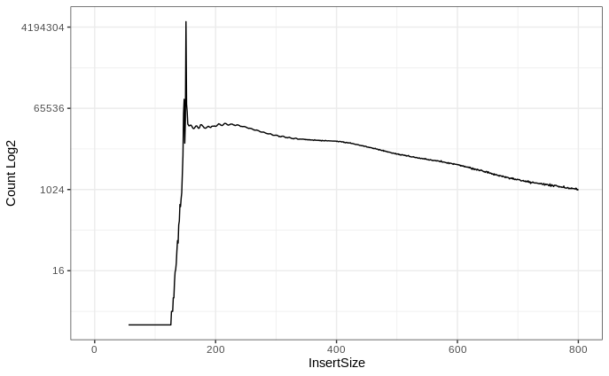

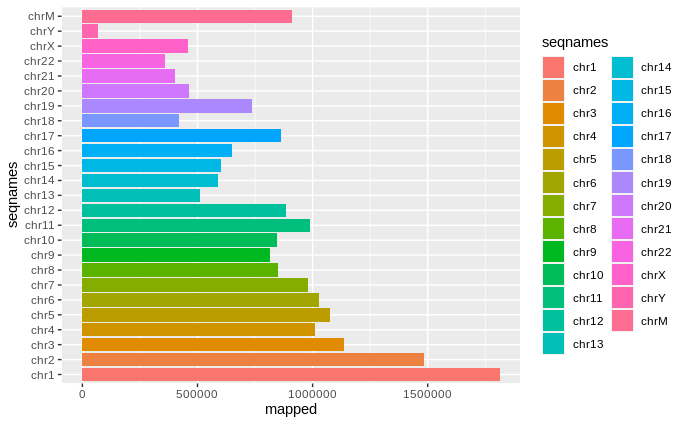

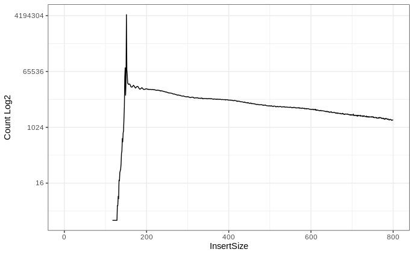

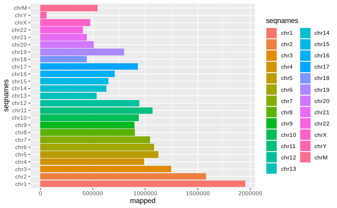

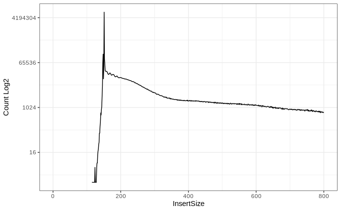

[12 more figures not shown]

```r
res_list
```

# ESC vs D5 NC Analysis

```r
NC_dba <- dba(sampleSheet="ESC_SampleSheet_NC.csv")
NC_dba <- dba.count(NC_dba)
# All ESC vs NC
#NC_dba <- dba.contrast(NC_dba, NC_dba$masks$ES, NC_dba$masks$NC)
# ESC vs D3
#NC_dba <- dba.contrast(NC_dba, NC_dba$masks$ES, NC_dba$masks$D3)
# ESC vs D5
# Negative fold change is enriched in D5, positive is enriched in ESC
NC_dba <- dba.contrast(NC_dba, NC_dba$masks$ES, NC_dba$masks$D5)
# D3 vs D5
#NC_dba <- dba.contrast(NC_dba, NC_dba$masks$D3, NC_dba$masks$D5)
NC_dba <- dba.analyze(NC_dba, bParallel = T)
NC_res <- dba.report(NC_dba)



# Make other PCA plot
dba.plotPCA(NC_dba)
meta_dataframe <- as.data.frame(NC_dba$class)
pca <- dba.plotPCA(NC_dba)
x <- pca$panel.args[[1]]$x
y <- pca$panel.args[[1]]$y
pca_mat <- as.data.frame(matrix(c(x,y), nrow = 6, ncol = 2, byrow = F))
colnames(pca_mat) <- c("PC1","PC2")
rownames(pca_mat) <- colnames(meta_dataframe)

pca_mat$timepoint <- factor(c("ES","ES","NC3","NC3",
                       "NC5","NC5"),
                       levels = c("ES","NC3","NC5"))
g <- ggplot(pca_mat, aes(x=PC1, y=PC2, color=timepoint)) +
  geom_point(size = 4, alpha = 1) +
  scale_color_npg() +
  labs(x = "PC1 64%" ,y = "PC2 22%") +
  theme(text=element_text(color="black", size = 10, face = "bold"),
        line=element_line(color="black", size = 2),
        axis.ticks = element_line(color = "black", size = 1),
        panel.background = element_blank(),
        panel.border = element_rect(fill=NA, color = "black", size = 2),
        axis.text = element_text(color="black", size = 10, face = "bold"),
        legend.key = element_blank()
  )

g

ggsave('./Exports/Human_ESC-to-iNC-PCA.eps', units = 'in', height = 4, width = 6, device = "eps")
```

## Exporting enriched peaksets.

## Run homer on ESC and NC enriched peaks

```bash
findMotifsGenome.pl D5_ESC_Enriched_5k.bed hg38 D5_ESC_Enriched_5k_HOMER -p 31

findMotifsGenome.pl D5_NC_Enriched_5k.bed hg38 D5_NC_Enriched_5k_HOMER -p 31
```

Results of this show strong Oct4, Sox2, and Oct4::Sox2 enrichment in ESC, good. And a lot of GATA2 results in D5 NC.

# ESC vs D3 NC Analysis

```r
NC_res_ann <- annotatePeak(NC_res, TxDb = TxDb_hg38)
```

```
>> preparing features information...         2020-07-10 11:56:03 AM
>> identifying nearest features...       2020-07-10 11:56:03 AM
>> calculating distance from peak to TSS...  2020-07-10 11:56:04 AM
>> assigning genomic annotation...       2020-07-10 11:56:04 AM
>> assigning chromosome lengths          2020-07-10 11:56:08 AM
>> done...                   2020-07-10 11:56:08 AM
```

```r
library(qdapTools)
NC_res_ann_df <- as.data.frame(NC_res_ann)
txs <- as.data.frame(transcripts(ensembl_human_annotation))
genes <- as.data.frame(genes(ensembl_human_annotation))
txs_lookup <- txs[,c("tx_id_version","gene_id")]
genes_lookup <- genes[,c("gene_id","gene_name")]
NC_res_ann_df$ENSEMBL <- lookup(NC_res_ann_df$transcriptId, txs_lookup)
NC_res_ann_df$Symbol <- lookup(NC_res_ann_df$ENSEMBL, genes_lookup)
NC_res_ann_df$peakID <- paste0(NC_res_ann_df$seqnames, "_",NC_res_ann_df$start,"_",NC_res_ann_df$end)
```

## Run homer on ESC and NC enriched peaks

```bash
findMotifsGenome.pl D3_NC_Enriched_5k.bed hg38 D3_NC_Enriched_5k_HOMER -p 31

findMotifsGenome.pl D3_ESC_Enriched_5k.bed hg38 D3_ESC_Enriched_5k_HOMER -p 31
```

# D3 vs D5 NC Analysis

```r
# ESC vs D3
NC_dba$contrasts=NULL
# D3 Enriched positive LogFC, D5 enriched Negative.
NC_dba <- dba.contrast(NC_dba, NC_dba$masks$D3, NC_dba$masks$D5)
NC_dba <- dba.analyze(NC_dba, bParallel = T)
NC_res <- dba.report(NC_dba)

NC_res_ann <- annotatePeak(NC_res, TxDb = TxDb_hg38)
```

```
>> preparing features information...         2020-07-10 12:08:42 PM
>> identifying nearest features...       2020-07-10 12:08:42 PM
>> calculating distance from peak to TSS...  2020-07-10 12:08:43 PM
>> assigning genomic annotation...       2020-07-10 12:08:43 PM
>> assigning chromosome lengths          2020-07-10 12:08:47 PM
>> done...                   2020-07-10 12:08:47 PM
```

```r
library(qdapTools)
NC_res_ann_df <- as.data.frame(NC_res_ann)
txs <- as.data.frame(transcripts(ensembl_human_annotation))
genes <- as.data.frame(genes(ensembl_human_annotation))
txs_lookup <- txs[,c("tx_id_version","gene_id")]
genes_lookup <- genes[,c("gene_id","gene_name")]
NC_res_ann_df$ENSEMBL <- lookup(NC_res_ann_df$transcriptId, txs_lookup)
NC_res_ann_df$Symbol <- lookup(NC_res_ann_df$ENSEMBL, genes_lookup)
NC_res_ann_df$peakID <- paste0(NC_res_ann_df$seqnames, "_",NC_res_ann_df$start,"_",NC_res_ann_df$end)
```

## Run homer on ESC and NC enriched peaks

```bash
findMotifsGenome.pl D3_NC_Enriched_5k.bed hg38 D3_NC_Enriched_5k_HOMER -p 31

findMotifsGenome.pl D3_ESC_Enriched_5k.bed hg38 D3_ESC_Enriched_5k_HOMER -p 31
```

## Normalized counts via DESeq2

While we have used diffbind to generate peaksets, we do not have an easy way to generate normalized counts directly from the diffbind object. Therefore, we must transform it into a DESeq2 object to generate a set of normalized counts for additional analysis.

```r
# Running DeSeq to get Rlog counts
library(DESeq2)
summarized_experiment2 <- dba(samples_ATAC, bSummarizedExperiment = T)
summarized_experiment2@assays@data$scores <- summarized_experiment2@assays@data$Reads
#order of counts not correct.
dds_experiment2 <- DESeqDataSet(summarized_experiment2, design = ~ Condition)
dds_experiment2 <- DESeq(dds_experiment2)
dds_results <- results(dds_experiment2)
rld <- rlog(dds_experiment2, blind = FALSE)
rownames(assay(rld)) <- paste0(samples_ATAC$peaks[[1]]$Chr,"_",samples_ATAC$peaks[[1]]$Start,"_",samples_ATAC$peaks[[1]]$End)
rld_df <- data.frame(row.names = paste0(samples_ATAC$peaks[[1]]$Chr,"_",samples_ATAC$peaks[[1]]$Start,"_",samples_ATAC$peaks[[1]]$End),
           assay(rld))

write.table(rld_df, file = "./Exports/Rlog_counts_All_ATAC_Peaks", quote = F, sep = "\t", row.names = T)

library(pheatmap)

rld_df_avg <- data.frame(HH6 = rowMeans(rld_df[c('HH6_1', 'HH6_2')], na.rm=TRUE),
                         HH8 = rowMeans(rld_df[c('HH8_1', 'HH8_2')], na.rm=TRUE),
                         HH10 = rowMeans(rld_df[c('HH10_1', 'HH10_2')], na.rm=TRUE),
                         HH12 = rowMeans(rld_df[c('HH12_1', 'HH12_2')], na.rm=TRUE),
                         HH14 = rowMeans(rld_df[c('HH14_1', 'HH14_2')], na.rm=TRUE),
                         HH16 = rowMeans(rld_df[c('HH16_2', 'HH16_2')], na.rm=TRUE),
                         HH18 = rowMeans(rld_df[c('HH18_1', 'HH18_2')], na.rm=TRUE))

write.table(rld_df_avg, file = "./Exports/Rlog_counts_avergae_All_ATAC_Peaks", quote = F, sep = "\t", row.names = T)

ATAC_clusters = pheatmap(subset(rld_df_avg, rownames(rld_df_avg) %in% top_18k_differential$peakID),
                         cluster_cols = F, scale = "row", show_rownames = F, show_colnames = T,
                         color = colorRampPalette(colors = c("#0797B3","#FFFFFF","#4FA14E"))(250),
                         filename = "./Exports/top_18k_peaks_heatmap.pdf", width = 6, height = 5)

#So it renders properly in html doc
pheatmap(subset(rld_df_avg, rownames(rld_df_avg) %in% top_18k_differential$peakID),
                         cluster_cols = F, scale = "row", show_rownames = F, show_colnames = T,
                         color = colorRampPalette(colors = c("#0797B3","#FFFFFF","#4FA14E"))(250))
```

While we generated early, mid, and late, peaks. There are some overlaping regions. To generate unique peaksets, we use bedtools.

```r
cd ~/local_git/NC_Timecourse/ATAC-Seq/Exports
bedtools intersect -wa -a early_peaks.bed -b mid_peaks.bed late_peaks.bed -v | uniq > early_peaks_uniq.bed
bedtools intersect -wa -a mid_peaks.bed -b early_peaks.bed late_peaks.bed -v | uniq > mid_peaks_uniq.bed
bedtools intersect -wa -a late_peaks.bed -b early_peaks.bed mid_peaks.bed -v | uniq > late_peaks_uniq.bed
```

Let’s visualize the signal at these peak sets across our samples.

```r
#making heatmaps
#RPKM normalized bw files
computeMatrix reference-point -S HH6_1.bw HH10_1.bw HH14_1.bw HH18_1.bw -R early_peaks_uniq.bed -b 1000 -a 1000 -bs 5 -o early_peaks_alt_timepoints.mat.gz  --missingDataAsZero --referencePoint center
plotHeatmap -m early_peaks_alt_timepoints.mat.gz -out early_peaks_alt_timepoints_2.png --colorMap Blues --dpi 600 --heatmapHeight 5

computeMatrix reference-point -S HH6_1.bw HH10_1.bw HH14_1.bw HH18_1.bw -R late_peaks_uniq.bed -b 1000 -a 1000 -bs 5 -o late_peaks_alt_timepoints.mat.gz  --missingDataAsZero --referencePoint center
plotHeatmap -m late_peaks_alt_timepoints.mat.gz -out late_peaks_alt_timepoints.png --colorMap Blues --dpi 600 --heatmapHeight 5

computeMatrix reference-point -S HH6_1.bw HH10_1.bw HH14_1.bw HH18_1.bw -R mid_peaks_uniq.bed -b 1000 -a 1000 -bs 5 -o mid_peaks_alt_timepoints.mat.gz  --missingDataAsZero --referencePoint center
plotHeatmap -m mid_peaks_alt_timepoints.mat.gz -out mid_peaks_alt_timepoints_2.png --colorMap Blues --dpi 600 --heatmapHeight 5 --yMax 450
```

```r
plotHeatmap -m ./Exports/early_peaks_alt_timepoints.mat.gz -out ./Exports/early_peaks_alt_timepoints_2.eps --colorList "#0797B3,#FFFFFF,#4FA14E" --dpi 600 --heatmapHeight 5
plotHeatmap -m ./Exports/late_peaks_alt_timepoints.mat.gz -out ./Exports/late_peaks_alt_timepoints.eps --colorList "#0797B3,#FFFFFF,#4FA14E" --dpi 600 --heatmapHeight 5
plotHeatmap -m ./Exports/mid_peaks_alt_timepoints.mat.gz -out ./Exports/mid_peaks_alt_timepoints_2.eps --colorList "#0797B3,#FFFFFF,#4FA14E" --dpi 600 --heatmapHeight 5 --yMax 450

gs -dSAFER -dEPSCrop -r300 -sDEVICE=pngalpha -o ./Exports/early_peaks_alt_timepoints_2.png ./Exports/early_peaks_alt_timepoints_2.eps
gs -dSAFER -dEPSCrop -r300 -sDEVICE=pngalpha -o ./Exports/late_peaks_alt_timepoints.png ./Exports/late_peaks_alt_timepoints.eps
gs -dSAFER -dEPSCrop -r300 -sDEVICE=pngalpha -o ./Exports/mid_peaks_alt_timepoints_2.png ./Exports/mid_peaks_alt_timepoints_2.eps
```